# ST1131 Introduction to Statistics and Statistical Computing

## Tutorial 6

```python
# Verify the notebook is using venv-st1131
# You should see either \venv-st1131\Scripts\python.exe or /venv-st1131/bin/python
import sys
from pathlib import Path
print(Path(*Path(sys.executable).parts[-3:]))
```

```
venv-st1131/bin/python
```

```python
# Verify required packages
import numpy as np
import pandas as pd
import matplotlib.pyplot as plt
from scipy import stats

print("Everything works!")
```

```
Everything works!
```

### Question 1

An exam consists of 50 multiple choice questions. Based on how much you studied, for any given question you think you have a probability of $p = 0.7$ of getting the correct answer. Consider the sampling distribution of the sample proportion $\hat{p}$ of the 50 questions on which you get the correct answer.

(a) Find the mean and standard deviation of the sampling distribution of this proportion.

Each question is either correct with probability $p=0.7$ or wrong. Sample size is $n=50$.  
The sampling distribution of the sample proportion, $\hat{p}$ has mean $0.7$ and standard deviation of:

$$ \sqrt{\frac{p(1-p)}{n}} = \sqrt{\frac{(0.3)(0.7)}{50}} \approx 0.0648 $$

(b) What do you expect for the shape of the sampling distribution? Why?

Since sample size $n=50$ and $np(1-p) = 50(0.3)(0.7) = 10.5$ is large enough, by CLT, the distribution of $\hat{p}$ can be approximated by a normal distribution.

(c) If true $p = 0.7$, then would it be surprising if you got the correct answer on at most 60% of the questions?

If true $p=0.7$ then

$$ \hat{p} \sim N\left(0.7, \frac{(0.3)(0.7)}{50}\right) $$

The probability of getting at most 60% correct answer is:

$$ P(\hat{p} \le 0.6) = P\left(Z \le \frac{0.6 - 0.7}{0.0648}\right) = P(Z \le -1.543) = 0.0614 $$

Since this probability is about 0.06, getting at most 60% correct would be somewhat unusual but not very surprising.

### Question 2

A supplier of electronic chips for tablets claims that only 4% of his chips are defective. A manufacturer tests 500 randomly selected chips from a large shipment from the supplier for potential defects.

(a) Find the mean and standard deviation for the distribution of the sample proportion of defective chips in the sample of 500.

Each chip is either defective with probability $0.04$ or not defective. Sample size is $n=500$.  
The proportion of defective chips in a sample is $\hat{p}$ which has distribution with mean $0.04$ and standard deviation of:

$$ \sqrt{\frac{p(1-p)}{n}} = \sqrt{\frac{(0.04)(0.96)}{500}} \approx 0.00876 $$

(b) Is it reasonable to assume a normal shape for the sampling distribution? Explain.

It is reasonable to assume a normal shape for the sampling distribution of $\hat{p}$, since the sample size $n=500$ and $np(1-p) = 500(0.04)(0.96) = 19.2$ is large enough.

(c) The manufacturer will return the entire shipment if he finds at least 5% of the 500 sampled chips to be defective.

Find the theoretical probability that the shipment will be returned, and use `scipy.stats.norm` to compute this probability in Python.

If true $p=0.04$, then

$$ \hat{p} \sim N\left(0.04, \frac{(0.04)(0.96)}{500}\right) $$

The shipment will be returned if from the sample we obtain a $\hat{p}$ that is 5% or larger. Hence, the probability that the shipment is returned is:

$$ P(\hat{p} \ge 0.05) = P\left(Z \ge \frac{0.05 - 0.04}{\sqrt{\frac{(0.04)(0.96)}{500}}}\right) = P(Z \ge 1.141) = 0.1269 $$

```python
p = 0.04
n = 500
se = np.sqrt(p * (1 - p) / n)
z = (0.05 - p) / se
prob_return = stats.norm.sf(0.05, loc=p, scale=se)

print(f"Standard Error: {se:.6f}")
print(f"Z-score: {z:.4f}")
print(f"P(p_hat >= 0.05): {prob_return:.4f}")
```

```
Standard Error: 0.008764
Z-score: 1.1411
P(p_hat >= 0.05): 0.1269
```

### Question 3

According to a recent Current Population Report, the population distribution of the number of years of education for self-employed individuals in the US has a mean of 13.6 and a standard deviation of 3.

(a) Identify the random variable $X$ whose population distribution is described here.

The random variable $X$ is the number of years of education for self-employed US individuals.

(b) Find the mean and standard deviation of the sampling distribution of $\bar{X}$ for a random sample of size $n = 100$. Interpret the results.

The mean is $13.6$ and the standard deviation is:

$$ \frac{\sigma}{\sqrt{n}} = \frac{3}{\sqrt{100}} = 0.3 $$

The mean of the sampling distribution is $13.6$, the same as the mean of the population.  
The standard deviation of the sampling distribution is smaller than the standard deviation of the population. It reflects the variability of the sample mean from samples of size $100$ taken from this population.

(c) Repeat part (b) for $n = 400$. Describe the effect of increasing $n$.

The mean of the sampling distribution is still $13.6$ and the standard deviation is:

$$ \frac{\sigma}{\sqrt{n}} = \frac{3}{\sqrt{400}} = 0.15 $$

As $n$ increases, the mean of the sampling distribution stays the same, but the standard deviation gets smaller.

### Question 4 (Simulation in Python)

Consider the duration of mobile phone calls of a P6 student. It is assumed to follow a distribution with mean $\mu = 2.8$ minutes and standard deviation $\sigma = 2.1$ minutes.

Use Python to answer the following questions.

(a) Assume that the duration of mobile phone calls of this student follows a normal distribution. Generate a random sample of duration for 45 calls (use `np.random.seed(42)` for reproducibility). Derive the sample mean and sample standard deviation.

```python
np.random.seed(42)
mu = 2.8
sigma = 2.1
n = 45

# Generate 1 sample of 45 calls from N(mu=2.8, sigma=2.1)
sample = np.random.normal(loc=mu, scale=sigma, size=n)
sample_mean = np.mean(sample)
sample_sd = np.std(sample, ddof=1)  # ddof=1 for sample standard deviation s

print(f"Sample mean (x_bar): {sample_mean:.4f}")
print(f"Sample standard deviation (s): {sample_sd:.4f}")
```

```
Sample mean (x_bar): 2.3459
Sample standard deviation (s): 1.9536
```

(b) Repeat part (a) for $N = 1000$ times. Store all the sample mean values in a NumPy array or list called `x_bar`.

```python
np.random.seed(42)
N = 1000

# Generate N samples of size n=45 simultaneously (matrix shape: 1000 x 45)
samples = np.random.normal(loc=mu, scale=sigma, size=(N, n))
x_bar = np.mean(samples, axis=1)

print(f"Generated {len(x_bar)} sample means.")
print(f"First 5 sample means: {np.round(x_bar[:5], 4)}")
```

```
Generated 1000 sample means.
First 5 sample means: [2.3459 2.8391 2.6647 3.1643 2.9568]
```

(c) Plot a histogram for `x_bar` using `matplotlib.pyplot`. Does the histogram resemble a bell-shaped curve? What is (roughly) the center of the histogram?

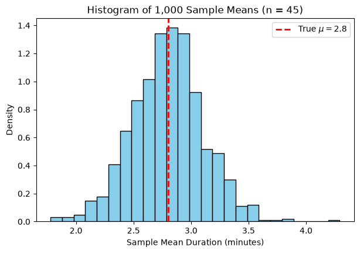

```python
plt.figure(figsize=(7, 4.5))
plt.hist(x_bar, bins=25, edgecolor="black", color="skyblue", density=True)
plt.axvline(mu, color="red", linestyle="--", linewidth=2, label=r"True $\mu = 2.8$")
plt.title("Histogram of 1,000 Sample Means (n = 45)")
plt.xlabel("Sample Mean Duration (minutes)")
plt.ylabel("Density")
plt.legend()
plt.show()
```

Yes, the histogram is symmetric and closely resembles a **bell-shaped (normal) curve**. The center of the histogram is located roughly around **2.8 minutes**, which aligns with the population mean $\mu = 2.8$.

(d) Derive the mean and standard deviation for `x_bar`. Are these values close to $2.8$ and $\left(2.1/\sqrt{45}\right)$ respectively?

```python
sim_mean = np.mean(x_bar)
sim_sd = np.std(x_bar, ddof=1)
theory_se = sigma / np.sqrt(n)

print(f"Simulated mean of x_bar: {sim_mean:.4f} | Theoretical mean: {mu}")
print(f"Simulated SD of x_bar:   {sim_sd:.4f} | Theoretical SE:   {theory_se:.4f}")
```

```
Simulated mean of x_bar: 2.8002 | Theoretical mean: 2.8
Simulated SD of x_bar:   0.3116 | Theoretical SE:   0.3130
```

Yes. The simulated mean of `x_bar` (approx. **2.8002**) is very close to $\mu = 2.8$, and the simulated standard deviation (approx. **0.3116**) is very close to the theoretical standard error $\sigma / \sqrt{n} = 2.1 / \sqrt{45} \approx 0.313$.

(e) Among all the values in `x_bar`, what proportion is larger than 3.5? Compare this with the theoretical probability $P(\bar{X} > 3.5)$, using the sampling distribution of $\bar{X}$.

```python
# Simulated proportion
count = np.sum(x_bar > 3.5)
sim_prop = np.mean(x_bar > 3.5)  # same as count / N

# Theoretical probability: X_bar ~ N(mu, sigma^2 / n)
se = sigma / np.sqrt(n)
theory_prob = stats.norm.sf(3.5, loc=mu, scale=se)

print(f"Number of sample means above 3.5: {count} out of {N}")
print(f"Simulated proportion:             {sim_prop:.4f}")
print(f"Theoretical probability:          {theory_prob:.4f}")
```

```
Number of sample means above 3.5: 16 out of 1000
Simulated proportion:             0.0160
Theoretical probability:          0.0127
```

Out of the 1000 simulated sample means, 16 are larger than 3.5, giving a proportion of 0.016.

Since the population is normal, $\bar{X} \sim N\left(2.8, \frac{2.1^2}{45}\right)$ exactly, with standard error $2.1/\sqrt{45} \approx 0.313$. Hence

$$ P(\bar{X} > 3.5) = P\left(Z > \frac{3.5 - 2.8}{0.313}\right) = P(Z > 2.24) \approx 0.0127. $$

The simulated proportion is close to the theoretical probability. They are not exactly equal because the simulation uses only $N = 1000$ samples: we would expect only about 13 sample means above 3.5, so a difference of a few values changes the proportion noticeably. Increasing $N$ would bring the simulated proportion closer to 0.0127.

### Question 5 (Simulation in Python)

A single roll of a fair six-sided die is about as far from "bell-shaped" as a distribution can get, it's perfectly flat (uniform), with outcomes $1$ to $6$ all equally likely. Let's use simulation to see what happens to the shape once we start *averaging* dice instead of looking at them one at a time.

Use Python to answer the following questions.

(a) Simulate $10{,}000$ rolls of a fair six-sided die (use `np.random.seed(0)` and `np.random.randint(1, 7, size=10000)` for reproducibility). Plot a histogram of the individual rolls. Describe the shape you see.

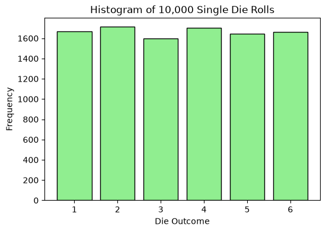

```python
np.random.seed(0)
rolls = np.random.randint(1, 7, size=10000)  # 10,000 single die rolls

plt.figure(figsize=(6, 4))
plt.hist(rolls, bins=np.arange(0.5, 7.5, 1), edgecolor="black", color="lightgreen", rwidth=0.8)
plt.title("Histogram of 10,000 Single Die Rolls")
plt.xlabel("Die Outcome")
plt.ylabel("Frequency")
plt.xticks(range(1, 7))
plt.show()
```

The histogram is roughly **flat / uniform**: each outcome from $1$ to $6$ occurs about the same number of times (about **1,667** out of $10{,}000$ rolls), as expected for a fair die. There is no bell shape at all here and every value is equally likely.

(b) Instead of single rolls, consider rolling $n$ dice at once and taking their average. Simulate $N = 5000$ such experiments for each of $n = 1, 5, 30$ dice, storing the sample mean of each experiment in three separate arrays: `means_n1`, `means_n5`, `means_n30`. (Use `np.random.seed(0)` again before each block for reproducibility.)

```python
N = 5000

np.random.seed(0)
means_n1 = np.random.randint(1, 7, size=(N, 1)).mean(axis=1)

np.random.seed(0)
means_n5 = np.random.randint(1, 7, size=(N, 5)).mean(axis=1)

np.random.seed(0)
means_n30 = np.random.randint(1, 7, size=(N, 30)).mean(axis=1)

print(f"means_n1  first 5: {np.round(means_n1[0:5], 4)}")
print(f"means_n5  first 5: {np.round(means_n5[0:5], 4)}")
print(f"means_n30 first 5: {np.round(means_n30[0:5], 4)}")
```

```
means_n1  first 5: [5. 6. 1. 4. 4.]
means_n5  first 5: [4.  3.8 3.  2.6 3.6]
means_n30 first 5: [3.3333 3.2333 3.6667 3.3667 3.    ]
```

(c) Plot the three histograms of the sample means for $n = 1, 5, 30$ side-by-side (as subplots) using `matplotlib.pyplot`. Describe how the shape changes as $n$ increases. What statistical result does this illustrate?

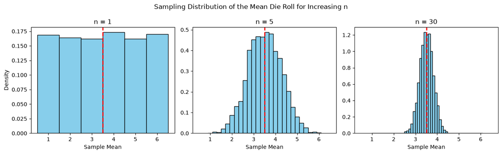

```python
fig, axes = plt.subplots(1, 3, figsize=(13, 4), sharex=True)
data_list = [means_n1, means_n5, means_n30]
titles = ["n = 1", "n = 5", "n = 30"]

# Bins aligned to the possible values of the sample mean for each n
bins_list = [
    np.arange(0.5, 7.5, 1),          # n = 1: values 1, 2, ..., 6
    np.arange(0.9, 6.2, 0.2),        # n = 5: values in steps of 0.2
    np.arange(1 - 1/60, 6.1, 0.1),   # n = 30: values in steps of 1/30, grouped 3 per bin
]

for ax, data, title, bins in zip(axes, data_list, titles, bins_list):
    ax.hist(data, bins=bins, edgecolor="black", color="skyblue", density=True)
    ax.axvline(3.5, color="red", linestyle="--", linewidth=2)
    ax.set_title(title)
    ax.set_xlabel("Sample Mean")

axes[0].set_ylabel("Density")
plt.suptitle("Sampling Distribution of the Mean Die Roll for Increasing n")
plt.tight_layout()
plt.show()
```

At **$n=1$** the distribution is still flat/uniform, just like the raw die rolls. As $n$ increases to **$n=5$** the distribution already looks noticeably more mound-shaped, and by **$n=30$** it is clearly **bell-shaped (approximately normal)** and much narrower, centered around $3.5$. This is the **Central Limit Theorem** in action: where even though a single die roll is far from normal, the sampling distribution of the *sample mean* becomes approximately normal as the sample size $n$ grows.

(d) A single die roll has population mean $\mu = 3.5$ and standard deviation $\sigma = \sqrt{\frac{35}{12}} \approx 1.708$. For each $n \in \{1, 5, 30\}$, compute the theoretical mean and standard error of the sample mean, and compare them to the simulated mean and standard deviation from part (b). You may present your results in a small table (e.g. using a `pandas` DataFrame).

```python
mu = 3.5
sigma = np.sqrt(sum((x - mu) ** 2 for x in range(1, 7)) / 6)

rows = []
for n, means in zip([1, 5, 30], [means_n1, means_n5, means_n30]):
    sim_mean = np.mean(means)
    sim_sd = np.std(means, ddof=1)
    theory_se = sigma / np.sqrt(n)
    rows.append((n, mu, sim_mean, theory_se, sim_sd))

summary = pd.DataFrame(
    rows, columns=["n", "Theoretical Mean", "Simulated Mean", "Theoretical SE", "Simulated SD"]
).round(4)
summary
```

|  | n | Theoretical Mean | Simulated Mean | Theoretical SE | Simulated SD |
| --- | --- | --- | --- | --- | --- |
| 0 | 1 | 3.5 | 3.5054 | 1.7078 | 1.7128 |
| 1 | 5 | 3.5 | 3.5070 | 0.7638 | 0.7645 |
| 2 | 30 | 3.5 | 3.5061 | 0.3118 | 0.3149 |

In every case, the simulated mean stays very close to the theoretical mean $\mu = 3.5$, and the simulated standard deviation is very close to the theoretical standard error $\sigma/\sqrt{n}$. As $n$ increases from $1 \to 5 \to 30$, the standard error **shrinks** (from about $1.71$ down to about $0.31$), which is why the histograms in part (c) got progressively narrower: larger samples give sample means that vary less around $\mu$.

(e) Suppose you need the sampling distribution of the mean to have a standard error no greater than $0.1$. Using the theoretical formula for the standard error, find the minimum number of dice $n$ required. Then verify computationally that this $n$ gives a simulated standard error close to your target.

```python
target_se = 0.1

# Solve sigma / sqrt(n) <= target_se  =>  n >= (sigma / target_se)^2
n_required = (sigma / target_se) ** 2
n_min = int(np.ceil(n_required))

print(f"Required n (raw): {n_required:.2f}")
print(f"Minimum whole number of dice needed: {n_min}")

# Verify computationally
np.random.seed(0)
means_check = np.random.randint(1, 7, size=(N, n_min)).mean(axis=1)
sim_se_check = np.std(means_check, ddof=1)

print(f"Simulated SE with n={n_min}: {sim_se_check:.4f}")
```

```
Required n (raw): 291.67
Minimum whole number of dice needed: 292
Simulated SE with n=292: 0.0983
```

Solving $\sigma/\sqrt{n} \le 0.1$ gives $n \ge (\sigma/0.1)^2 = (1.708/0.1)^2 \approx 291.67$, so we need at least **$n = 292$** dice. Simulating with $n=292$ gives a simulated standard error of approximately **$0.098$**, which is indeed close to (and just under) the target of $0.1$, confirming the theoretical calculation.